# Madhuri PAtil -Loan risk EDA Project python

# C. Multivariate analysis

```python
con
```

```
['Income', 'Age', 'Experience', 'CURRENT_JOB_YRS', 'CURRENT_HOUSE_YRS']
```

```python
corr = df.corr(numeric_only= True)
```

```python
corr
```

|  | Income | Age | Experience | CURRENT_JOB_YRS | CURRENT_HOUSE_YRS |
| --- | --- | --- | --- | --- | --- |
| Income | 1.000000 | -0.000652 | 0.006422 | 0.007045 | -0.002397 |
| Age | -0.000652 | 1.000000 | -0.001118 | 0.002154 | -0.020134 |
| Experience | 0.006422 | -0.001118 | 1.000000 | 0.646098 | 0.019309 |
| CURRENT_JOB_YRS | 0.007045 | 0.002154 | 0.646098 | 1.000000 | 0.005372 |
| CURRENT_HOUSE_YRS | -0.002397 | -0.020134 | 0.019309 | 0.005372 | 1.000000 |

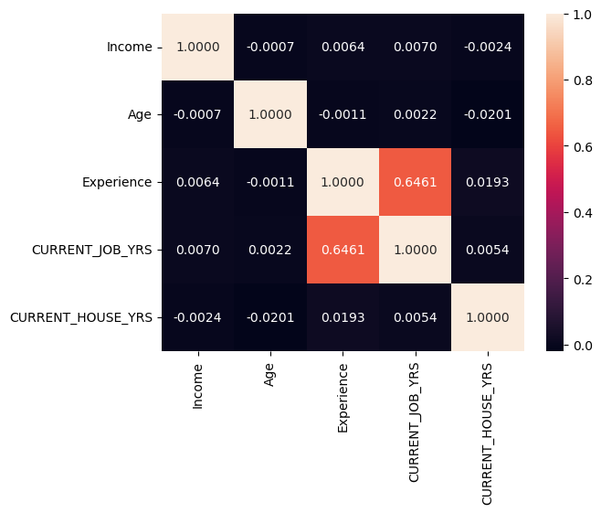

```python
sns.heatmap(data= corr, annot = True, fmt= ".4f")
```

## from above graph I can say that experience and current job years are positively correlated

### Other features do not have any correlation with each other in the given data

```python
g = df.groupby(by = "STATE" ).median (numeric_only= True)
g
```

| STATE | Income | Age | Experience | CURRENT_JOB_YRS | CURRENT_HOUSE_YRS |
| --- | --- | --- | --- | --- | --- |
| Andhra_Pradesh | 5125951.0 | 50.0 | 10.0 | 6.0 | 12.0 |
| Assam | 4536163.0 | 53.0 | 10.0 | 6.0 | 12.0 |
| Bihar | 4954336.5 | 50.0 | 10.0 | 6.0 | 12.0 |
| Chandigarh | 3757777.0 | 53.0 | 12.0 | 6.0 | 13.0 |
| Chhattisgarh | 5377559.0 | 53.0 | 10.0 | 6.0 | 12.0 |
| Delhi | 4678149.0 | 52.0 | 10.0 | 6.0 | 12.0 |
| Gujarat | 5265885.0 | 50.0 | 10.0 | 6.0 | 12.0 |
| Haryana | 4806341.0 | 51.0 | 11.0 | 6.0 | 12.0 |
| Himachal_Pradesh | 3890518.0 | 44.0 | 13.0 | 6.0 | 12.0 |
| Jammu_and_Kashmir | 3991574.0 | 52.0 | 10.0 | 6.0 | 12.0 |
| Jharkhand | 5240713.0 | 49.0 | 10.0 | 5.0 | 12.0 |
| Karnataka | 4726819.0 | 52.0 | 9.0 | 6.0 | 12.0 |
| Kerala | 5421502.0 | 52.0 | 8.0 | 6.0 | 12.0 |
| Madhya_Pradesh | 4735088.0 | 49.0 | 11.0 | 6.0 | 12.0 |
| Maharashtra | 5192166.5 | 50.0 | 10.0 | 6.0 | 12.0 |
| Manipur | 6001312.0 | 45.0 | 11.0 | 5.0 | 12.0 |
| Mizoram | 5090745.0 | 41.0 | 6.0 | 5.0 | 11.0 |
| Odisha | 4834921.5 | 50.0 | 12.0 | 6.0 | 12.0 |
| Puducherry | 3829485.0 | 51.0 | 9.0 | 5.0 | 12.0 |
| Punjab | 5047941.0 | 48.0 | 11.0 | 6.0 | 12.0 |
| Rajasthan | 5315413.0 | 49.0 | 10.0 | 6.0 | 12.0 |
| Sikkim | 5468271.0 | 43.0 | 10.0 | 4.5 | 13.0 |
| Tamil_Nadu | 5074244.0 | 51.0 | 10.0 | 6.0 | 12.0 |
| Telangana | 4942553.0 | 47.0 | 9.0 | 6.0 | 12.0 |
| Tripura | 3843088.0 | 54.0 | 11.0 | 7.0 | 12.0 |
| Uttar_Pradesh | 4763842.0 | 50.0 | 10.0 | 6.0 | 12.0 |
| Uttarakhand | 4706227.0 | 48.0 | 10.0 | 6.0 | 12.0 |
| West_Bengal | 5134357.0 | 50.0 | 10.0 | 6.0 | 12.0 |

# Pairlpot`

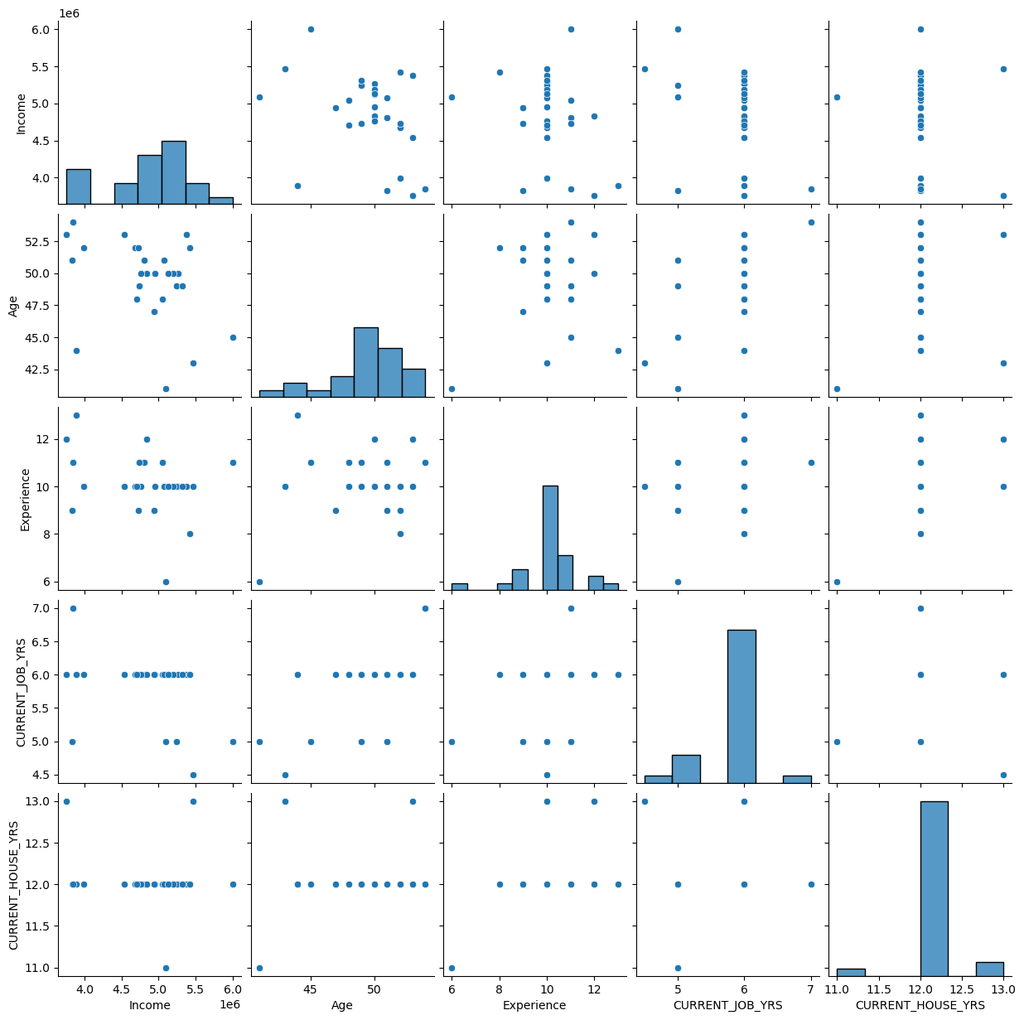

```python
sns.pairplot(g)
```

# 10 Complex Questions to Investigate

## 1. Which are the top 5 states with the highest number of High Risk

applicants?

```python
q1 = df.query("Risk == 'High'")\
    .groupby(by= "STATE")\
    .agg({"Risk": "count"})\
    .sort_values(by = "Risk", ascending = False)\
    .head()
```

```python
q1
```

| STATE | Risk |
| --- | --- |
| Uttar_Pradesh | 3440 |
| West_Bengal | 3009 |
| Andhra_Pradesh | 2935 |
| Maharashtra | 2895 |
| Bihar | 2583 |

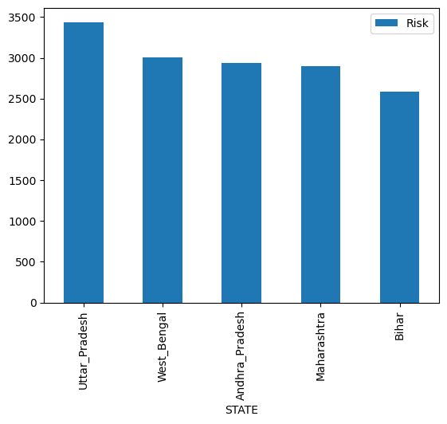

```python
q1.plot(kind = ("bar"))
```

# 2.What are the top 3 professions with the highest occurrence of High Risk classifications?

```python
q2 = df.query("Risk == 'High'")\
   .groupby(by = "Profession")\
    .agg({"Risk": "count"})\
    .sort_values(by = "Risk" , ascending = False)\
    .head(3)
```

```python
q2
```

| Profession | Risk |
| --- | --- |
| Police_officer | 826 |
| Software_Developer | 750 |
| Air_traffic_controller | 715 |

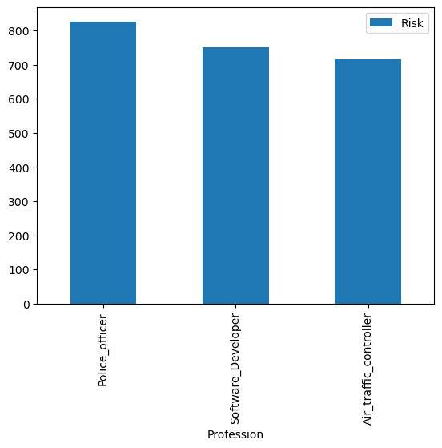

```python
q2.plot(kind= "bar")
```

# 3. Which cities record the most High Risk applicants compared to others?

```python
q3= df.query("Risk == 'High'")\
   .groupby(by = "CITY")\
    .agg({"Risk": "count"})\
    .sort_values(by = "Risk" , ascending = False)\
    .head(10)
```

```python
q3
```

| CITY | Risk |
| --- | --- |
| Kochi | 243 |
| Satna | 232 |
| Buxar | 228 |
| Srinagar | 216 |
| Indore | 212 |
| Barasat | 206 |
| Mango | 200 |
| Bhubaneswar | 198 |
| Ghaziabad | 196 |
| Sikar | 191 |

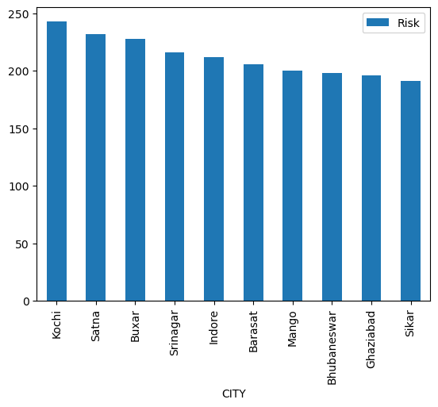

```python
q3.plot(kind= "bar")
```

# 4. How does the income distribution vary between High Risk and Low Risk applicants?

```python
df.groupby (by= "Risk").describe(exclude = "object") ["Income"].round(2).T
```

| Risk | High | Low |
| --- | --- | --- |
| count | 30996.00 | 221004.00 |
| mean | 4973358.84 | 5000448.72 |
| std | 2921064.50 | 2872254.90 |
| min | 10675.00 | 10310.00 |
| 25% | 2421029.00 | 2520632.75 |
| 50% | 4977653.00 | 5002134.00 |
| 75% | 7556052.00 | 7470480.00 |
| max | 9994501.00 | 9999938.00 |

## There is no difference in income of high risk and low risk on this data

# Q5. What age groups are most represented among High Risk applicants?

```python
df.groupby (by= "Risk").describe(exclude = "object") ["Age"].round(2).T
```

| Risk | High | Low |
| --- | --- | --- |
| count | 30996.00 | 221004.00 |
| mean | 48.96 | 50.09 |
| std | 17.37 | 17.02 |
| min | 21.00 | 21.00 |
| 25% | 33.00 | 35.00 |
| 50% | 49.00 | 50.00 |
| 75% | 64.00 | 65.00 |
| max | 79.00 | 79.00 |

```python
ctab_q5= pd.crosstab(df ["Age"], df["Risk"])
```

```python
ctab_q5
```

| Risk Age | High | Low |
| --- | --- | --- |
| 21 | 598 | 3607 |
| 22 | 770 | 3660 |
| 23 | 536 | 3786 |
| 24 | 631 | 3695 |
| 25 | 584 | 3959 |
| 26 | 719 | 3437 |
| 27 | 720 | 4477 |
| 28 | 602 | 3299 |
| 29 | 569 | 3540 |
| 30 | 589 | 3879 |
| 31 | 531 | 3726 |
| 32 | 498 | 3336 |
| 33 | 719 | 4202 |
| 34 | 354 | 4060 |
| 35 | 513 | 4130 |
| 36 | 454 | 2990 |
| 37 | 526 | 3627 |
| 38 | 490 | 3303 |
| 39 | 417 | 3383 |
| 40 | 370 | 3863 |
| 41 | 570 | 4257 |
| 42 | 519 | 3615 |
| 43 | 436 | 3770 |
| 44 | 388 | 3234 |
| 45 | 589 | 4217 |
| 46 | 543 | 3084 |
| 47 | 616 | 3867 |
| 48 | 578 | 4389 |
| 49 | 443 | 3760 |
| 50 | 550 | 4074 |
| 51 | 385 | 3012 |
| 52 | 370 | 2827 |
| 53 | 501 | 3989 |
| 54 | 660 | 4125 |
| 55 | 582 | 3981 |
| 56 | 515 | 3829 |
| 57 | 531 | 3863 |
| 58 | 463 | 3905 |
| 59 | 591 | 3907 |
| 60 | 532 | 3972 |
| 61 | 563 | 3672 |
| 62 | 464 | 3847 |
| 63 | 511 | 3431 |
| 64 | 374 | 3758 |
| 65 | 512 | 3457 |
| 66 | 737 | 4355 |
| 67 | 407 | 3588 |
| 68 | 451 | 4321 |
| 69 | 497 | 4120 |
| 70 | 481 | 3770 |
| 71 | 458 | 3692 |
| 72 | 570 | 3963 |
| 73 | 417 | 3152 |
| 74 | 429 | 3525 |
| 75 | 395 | 3434 |
| 76 | 666 | 3919 |
| 77 | 459 | 3457 |
| 78 | 540 | 3915 |
| 79 | 513 | 3992 |

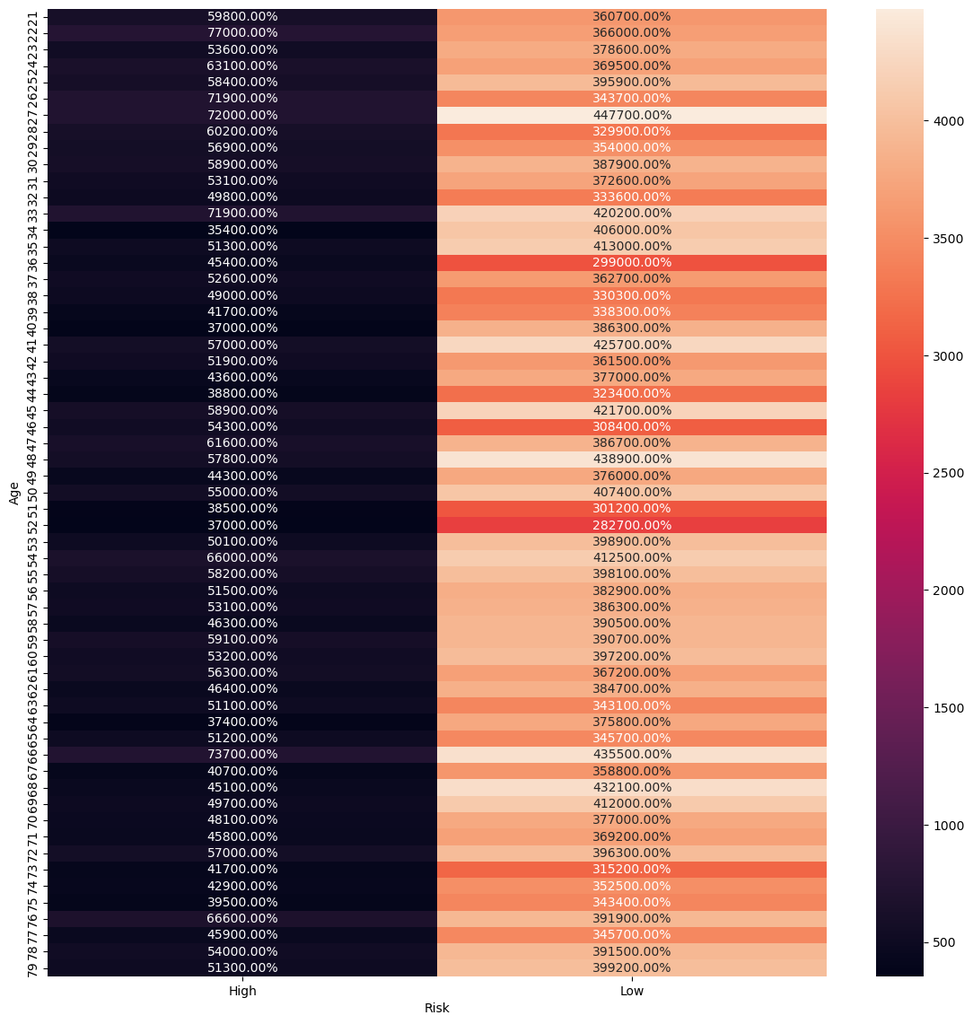

```python
plt.figure(figsize= (14,14))
sns.heatmap(data= ctab_q5, annot= True, fmt= ".2%")
plt.show()
```

# Q6. ow does house ownership (rented vs. owned) influence the distribution of High Risk applicants?

```python
ctab_q6= pd.crosstab(df["House_Ownership"], df["Risk"], normalize = "index")
ctab_q6
```

| Risk House_Ownership | High | Low |
| --- | --- | --- |
| norent_noown | 0.099527 | 0.900473 |
| owned | 0.089797 | 0.910203 |
| rented | 0.125577 | 0.874423 |

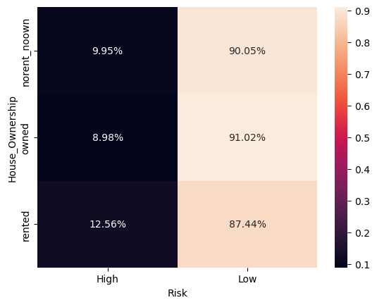

```python
sns.heatmap(data=ctab_q6 , annot= True, fmt= ".2%")
```

## people with rented home tend to have high risk compared to others

# Q7. What are the patterns of car ownership among High Risk versus Low Risk applicants?

```python
ctab_q7= pd.crosstab(df["Car_Ownership"], df["Risk"], normalize="index")
ctab_q7
```

| Risk Car_Ownership | High | Low |
| --- | --- | --- |
| no | 0.128188 | 0.871812 |
| yes | 0.110987 | 0.889013 |

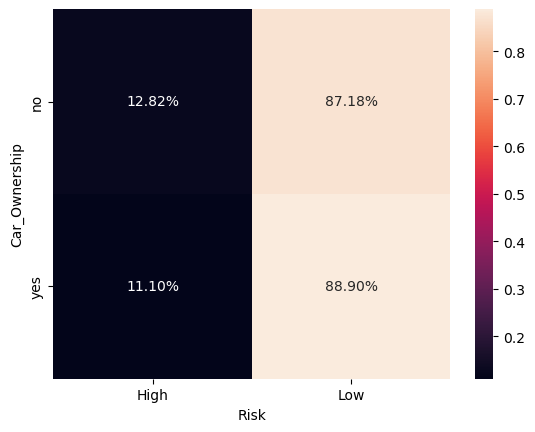

```python
sns.heatmap(data=ctab_q7 , annot= True, fmt= ".2%")
```

# Q8. How does the duration in current jobs (CURRENT_JOB_YRS) differ between High Risk and Low Risk groups?

```python
df.groupby (by= "Risk").describe(exclude = "object") ["CURRENT_JOB_YRS"].round(2).T
```

| Risk | High | Low |
| --- | --- | --- |
| count | 30996.00 | 221004.00 |
| mean | 6.17 | 6.36 |
| std | 3.75 | 3.63 |
| min | 0.00 | 0.00 |
| 25% | 3.00 | 4.00 |
| 50% | 6.00 | 6.00 |
| 75% | 9.00 | 9.00 |
| max | 14.00 | 14.00 |

# Q9. What trends in overall work experience are evident among High Risk applicants?

```python
df.groupby (by= "Risk").describe(exclude = "object") ["Experience"].round(2).T
```

| Risk | High | Low |
| --- | --- | --- |
| count | 30996.00 | 221004.00 |
| mean | 9.53 | 10.16 |
| std | 6.07 | 5.99 |
| min | 0.00 | 0.00 |
| 25% | 4.00 | 5.00 |
| 50% | 9.00 | 10.00 |
| 75% | 15.00 | 15.00 |
| max | 20.00 | 20.00 |

# Q10. Which marital status (married vs. single) shows a higher prevalence of High Risk applicants?

```python
ctab_q10= pd.crosstab(df["Married/Single"], df["Risk"], normalize="index")
ctab_q10
```

| Risk Married/Single | High | Low |
| --- | --- | --- |
| married | 0.102456 | 0.897544 |
| single | 0.125336 | 0.874664 |

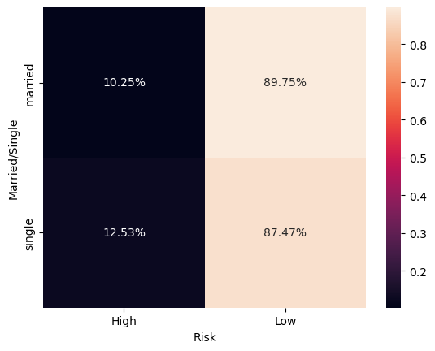

```python
sns.heatmap(data=ctab_q10 , annot= True, fmt= ".2%")
```

# Single people tend to have higher risk than married people